# Pathway enrichment analysis and visualization using clusterProfiler

2024-10-10

This R Markdown tutorial was created to perform enrichment analysis on Gene Ontology. GO terms are organized in a directed acyclic graph, where edges between terms represent parent-child relationship.

If you use clusterProfiler in published research, please cite:

G Yu, LG Wang, Y Han, QY He. clusterProfiler: an R package for comparing biological themes among gene clusters. OMICS: A Journal of Integrative Biology 2012, 16(5):284-287. doi:[10.1089/omi.2011.0118](http://dx.doi.org/10.1089/omi.2011.0118)

# 1 Load packages

```r
library(tidyverse)
library(clusterProfiler)
```

```r
library(ggplot2)
library(org.Hs.eg.db)
```

# 2 Load gene list and convert them to EntrezID

```r
example_gene_list <- c("GPX3",  "GLRX",   "LBP",   "CRYAB", "DEFB1", "HCLS1",   "SOD2",   "HSPA2",
       "ORM1",  "IGFBP1", "PTHLH", "GPC3",  "IGFBP3","TOB1",    "MITF",   "NDRG1",
       "NR1H4", "FGFR3",  "PVR",   "IL6",   "PTPRM", "ERBB2",   "NID2",   "LAMB1",
       "COMP",  "PLS3",   "MCAM",  "SPP1",  "LAMC1", "COL4A2",  "COL4A1", "MYOC",
       "ANXA4", "TFPI2",  "CST6",  "SLPI",  "TIMP2", "CPM",     "GGT1",   "NNMT",
       "MAL",   "EEF1A2", "HGD",   "TCN2",  "CDA",   "PCCA",    "CRYM",   "PDXK",
       "STC1",  "WARS",  "HMOX1", "FXYD2", "RBP4",   "SLC6A12", "KDELR3", "ITM2B")

example_gene_mapping = bitr(example_gene_list, fromType="SYMBOL", toType="ENTREZID", OrgDb="org.Hs.eg.db")
example_gene_id <- example_gene_mapping$ENTREZID

# geneList is a pre-defined background gene list, and can be replaced with all genes in your datasets
data(geneList, package="DOSE")
```

# 3 GO over-representation analysis

The clusterProfiler package implements enrichGO() for gene ontology over-representation test.

Here we use the dataset geneList provided by DOSE.

Gene Ontology defines concepts/classes used to describe gene function, and relationships between these concepts. It classifies functions along three aspects:

- MF: Molecular Function: molecular activities of gene products
- CC: Cellular Component: where gene products are active
- BP: Biological Process: pathways and larger processes made up of the activities of multiple gene products

GO terms are organized in a directed acyclic graph, where edges between terms represent parent-child relationship.

```r
gobp_result <- enrichGO(gene          = example_gene_id,
                universe      = names(geneList),
                OrgDb         = org.Hs.eg.db,
                ont           = "BP", # can be either one: BP, MF, CC
                pAdjustMethod = "BH",
                pvalueCutoff  = 0.05,
                qvalueCutoff  = 0.05,
        readable      = TRUE)
head(gobp_result)
```

```
##                    ID                    Description GeneRatio   BgRatio
## GO:0001503 GO:0001503                   ossification     10/55 357/11586
## GO:0071711 GO:0071711 basement membrane organization      4/55  33/11586
##            RichFactor FoldEnrichment   zScore       pvalue   p.adjust
## GO:0001503  0.0280112       5.900688 6.495558 5.780792e-06 0.01038230
## GO:0071711  0.1212121      25.533884 9.747018 1.679054e-05 0.01507791
##                 qvalue                                               geneID
## GO:0001503 0.009468328 PTHLH/GPC3/IGFBP3/TOB1/FGFR3/IL6/COMP/SPP1/MYOC/STC1
## GO:0071711 0.013750572                              NID2/LAMB1/LAMC1/COL4A1
##            Count
## GO:0001503    10
## GO:0071711     4
```

# 4 Reactome pathway over-representation analysis

Enrichment analysis is a widely used approach to identify biological themes. ReactomePA implemented enrichPathway() that uses hypergeometric model to assess whether the number of selected genes associated with a reactome pathway is larger than expected.

```r
#BiocManager::install("ReactomePA")
library(ReactomePA)
reactome_result <- enrichPathway(gene=example_gene_id, pvalueCutoff = 0.05, readable=TRUE)
head(reactome_result)
```

```
##                          ID
## R-HSA-3000157 R-HSA-3000157
## R-HSA-8957275 R-HSA-8957275
## R-HSA-381426   R-HSA-381426
## R-HSA-3000178 R-HSA-3000178
## R-HSA-1474228 R-HSA-1474228
## R-HSA-1474244 R-HSA-1474244
##                                                                                                                               Description
## R-HSA-3000157                                                                                                        Laminin interactions
## R-HSA-8957275                                                                                  Post-translational protein phosphorylation
## R-HSA-381426  Regulation of Insulin-like Growth Factor (IGF) transport and uptake by Insulin-like Growth Factor Binding Proteins (IGFBPs)
## R-HSA-3000178                                                                                                           ECM proteoglycans
## R-HSA-1474228                                                                                     Degradation of the extracellular matrix
## R-HSA-1474244                                                                                           Extracellular matrix organization
##               GeneRatio   BgRatio       pvalue     p.adjust       qvalue
## R-HSA-3000157      5/45  30/11091 1.155704e-07 3.174599e-05 2.692580e-05
## R-HSA-8957275      7/45 108/11091 2.283884e-07 3.174599e-05 2.692580e-05
## R-HSA-381426       7/45 125/11091 6.205201e-07 5.750153e-05 4.877071e-05
## R-HSA-3000178      5/45  76/11091 1.304567e-05 9.066738e-04 7.690077e-04
## R-HSA-1474228      6/45 140/11091 1.974014e-05 1.090683e-03 9.250772e-04
## R-HSA-1474244      8/45 300/11091 2.353991e-05 1.090683e-03 9.250772e-04
##                                                       geneID Count
## R-HSA-3000157                 NID2/LAMB1/LAMC1/COL4A2/COL4A1     5
## R-HSA-8957275        IGFBP1/GPC3/IGFBP3/IL6/LAMB1/SPP1/LAMC1     7
## R-HSA-381426         IGFBP1/GPC3/IGFBP3/IL6/LAMB1/SPP1/LAMC1     7
## R-HSA-3000178                 LAMB1/COMP/LAMC1/COL4A2/COL4A1     5
## R-HSA-1474228           LAMB1/SPP1/LAMC1/COL4A2/COL4A1/TIMP2     6
## R-HSA-1474244 NID2/LAMB1/COMP/SPP1/LAMC1/COL4A2/COL4A1/TIMP2     8
```

# 5 Pathway visualization

## 5.1 Bar plot

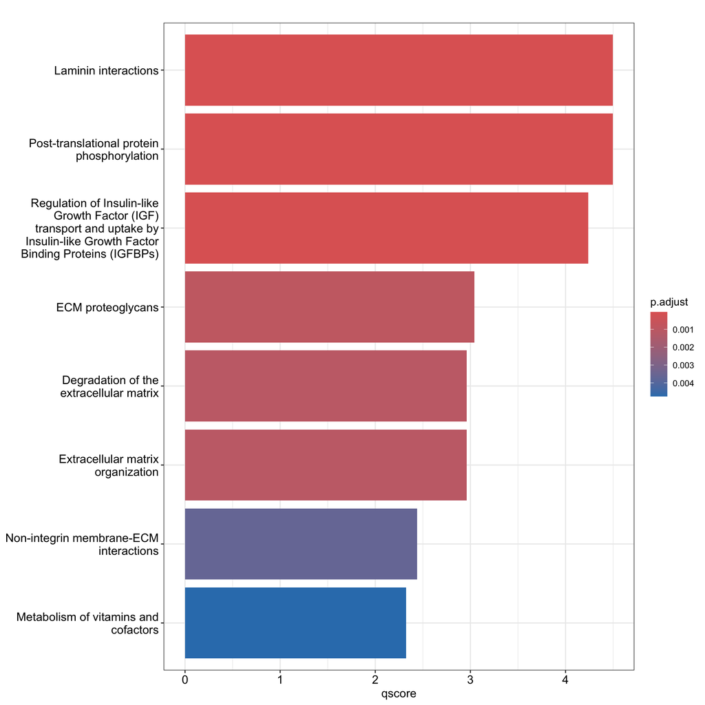

```r
mutate(reactome_result, qscore = -log(p.adjust, base=10)) %>%
    barplot(x="qscore")
```

## 5.2 Dot plot

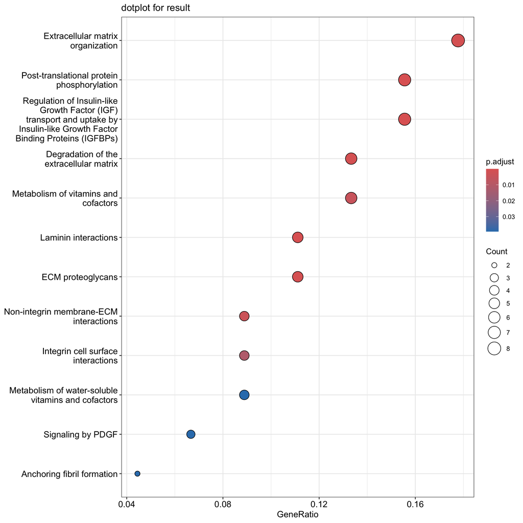

```r
dotplot(reactome_result, showCategory=30) + ggtitle("dotplot for result")
```

## Gene-Concept Network

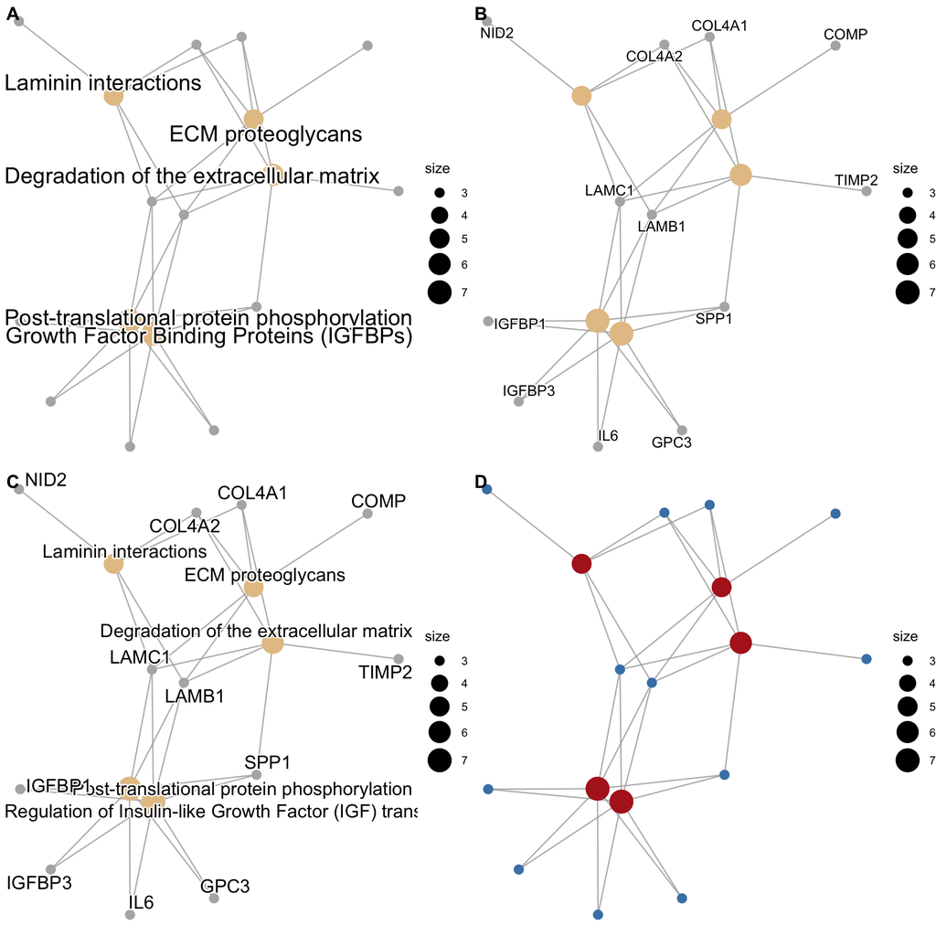

```r
p1 <- cnetplot(reactome_result, node_label="category",
        cex_label_category = 1.2)
p2 <- cnetplot(reactome_result, node_label="gene",
        cex_label_gene = 0.8)
p3 <- cnetplot(reactome_result, node_label="all")
p4 <- cnetplot(reactome_result, node_label="none",
        color_category='firebrick',
        color_gene='steelblue')
cowplot::plot_grid(p1, p2, p3, p4, ncol=2, labels=LETTERS[1:4])
```

## 5.3 Enrichment Map

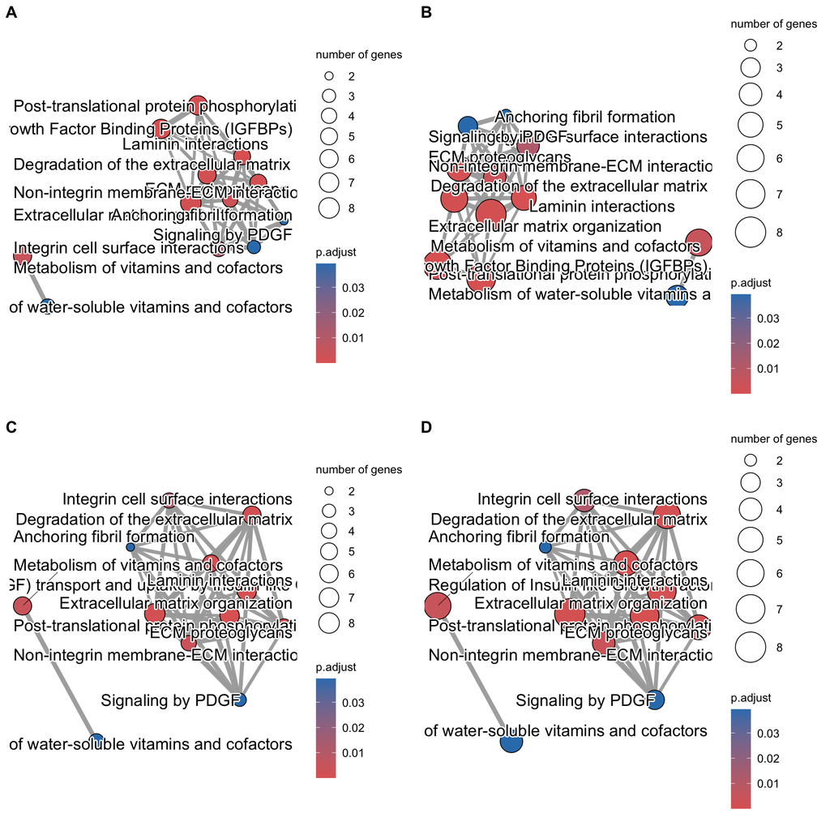

```r
library(enrichplot)
edo <- pairwise_termsim(reactome_result)
p1 <- emapplot(edo)
p2 <- emapplot(edo, cex_category=1.5)
p3 <- emapplot(edo, layout="kk")
p4 <- emapplot(edo, cex_category=1.5,layout="kk")
cowplot::plot_grid(p1, p2, p3, p4, ncol=2, labels=LETTERS[1:4])
```